# Data Science Assignment 2

Matt Wanner

2/23/2023

#### INSTRUCTIONS:

- Type your answers on the space provided under each problem.
- You can embed an R code chunk like this:

  ```r
  summary(cars)
  ```

  ```
  ##      speed           dist
  ##  Min.   : 4.0   Min.   :  2.00
  ##  1st Qu.:12.0   1st Qu.: 26.00
  ##  Median :15.0   Median : 36.00
  ##  Mean   :15.4   Mean   : 42.98
  ##  3rd Qu.:19.0   3rd Qu.: 56.00
  ##  Max.   :25.0   Max.   :120.00
  ```

- After you are done click the **Knit HTML** button. A document will be generated that includes both content as well as the output of any embedded R code chunks within the document.
- Go to File –> Save. Name your file.
- Upload the file to Canvas by using the link provided.

#### Before you begin:

1. In order to answer these questions you will need to load the NHANES data-set (refer to Assignment 1 (and `Package Pandemonium` for more information). Use NHANES 1.0.
2. Good graphical representations of data clearly indicate the important relationships in an easy to interpret fashion. (At least that’s the ideal). To this end, it is important to label your axes (axes is the plural of axis) and provide a title for the graph. These features are controlled with the named arguments `xlab=`, `ylab=`, and `main=`. Be sure to include these details in your answers. (examples are included in the questions below).

##### Problem 1. (8 points)

Your first problem involves graphical summaries of categorical data. One such summary is called a **barplot**. A barplot looks like a histogram (in fact a histogram is a type of barplot), but the functions you use to generate the graphics are different and designed to work with different types of data: A histogram deals with continuous numeric data, and a barplot deals with categorical data. The functions used are `hist()` and `barplot()` respectively. The two functions also differ in how they process the data. The function `hist()` is expecting a vector of numeric values which it divides into equal-sized bins before counting and then displaying. In contrast, `barplot()` is expecting data in a very specific fashion. We will use the `table()` function (discussed in Chapter 12 of your book) to process our raw data into a format usable by `table()`.

#### Plotting a frequency table

We generate a **frequency table** using the `table()` function:

```r
table(NHANES$smoker)
```

```
##
##   yes    no
##  4126 25249
```

and then use R’s defaults to plot the tabulated results:

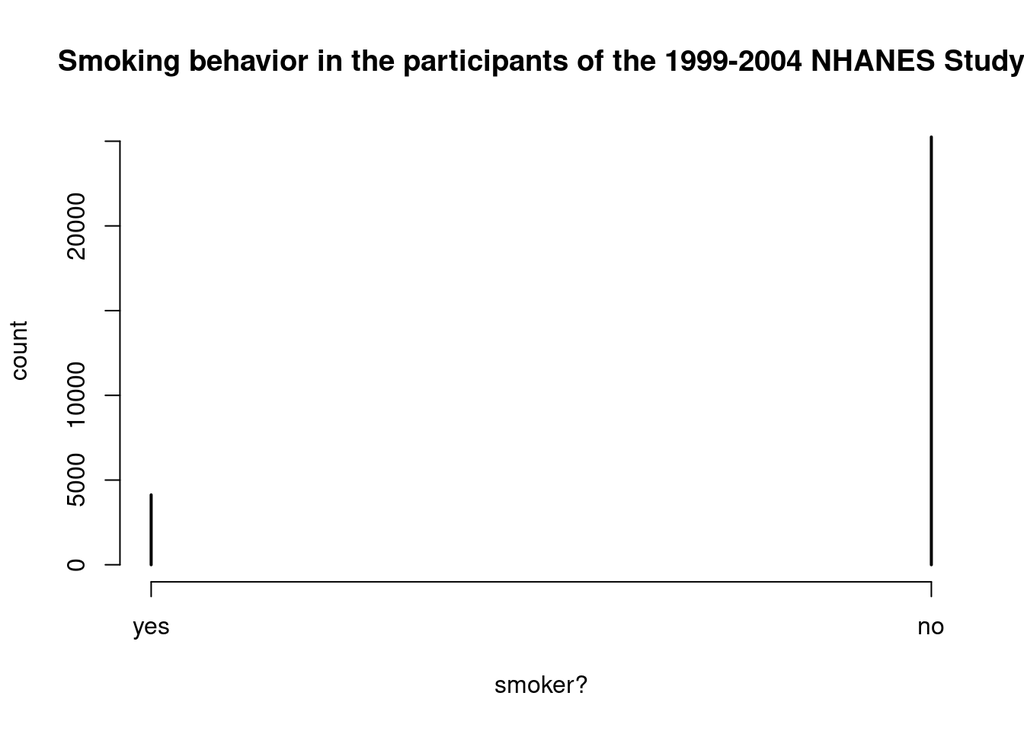

```r
plot(table(NHANES$smoker),xlab="smoker?",ylab="count",main="Smoking behavior in the participants of the 1999-2004 NHANES Study")
```

This graph is missing a few details that might be important for our audience to properly interpret the data: Perhaps we want to tell them how many participants were in the study or how many of those subjects are *not* included in the graph because their entry had a value of `NA` value.

Let’s figure out the following:

- How many subjects are in the NHANES study,
- and how many of those had a missing value for `$smoker`.

There are many ways to extract that information (`summary()` works just fine, for example), but I want to introduce you to a technique that is far more flexible and that we will generalize to more complicated situations in future assignments (so make certain you understand how this works):

```r
length(NHANES$smoker)
```

```
## [1] 31126
```

```r
sum(is.na(NHANES$smoker))
```

```
## [1] 1751
```

As you can see, the number of subjects, 31,126, is the `length()` of the *smoker* variable (which I will often refer to as `$smoker` to remind you that the data is stored in a column named *smoker* in some data-frame.). Perhaps a bit more mysterious is the expression that calculates the number of *missing values* as 1,751. This expression makes use of a very convenient feature of R– namely that the values `TRUE` and `FALSE` are converted to 0’s and 1’s in an expression that expects a number.

Let’s step through this idea:

1. The expression `NHANES$smoker` is a vector of values (of type *factor*).
2. The function `is.na()` applies a test to each in turn– asking “are you an `NA` (missing value)?”.
3. This generates a vector of logicals.
4. Applying `sum()` to the vector of logicals turns the `TRUE` values into 1, and the `FALSE` values into 0, then adds them.

Together, these 4 steps have the effect of counting the number of TRUE’s. Reread that last paragraph then see if you can make sense of what follows:

```r
head(NHANES$smoker)        # original values
```

```
## [1] no  no  no  no  yes no
## Levels: yes no
```

```r
head(is.na(NHANES$smoker)) # TRUE for NA's, FALSE otherwise
```

```
## [1] FALSE FALSE FALSE FALSE FALSE FALSE
```

```r
sum(is.na(NHANES$smoker))  # Count the number of TRUE's
```

```
## [1] 1751
```

Now let’s graph our table and include this supplementary information using the `sub=` argument. Please note that I am using `plot()` and not `barplot()` (that comes later). The difference is important:

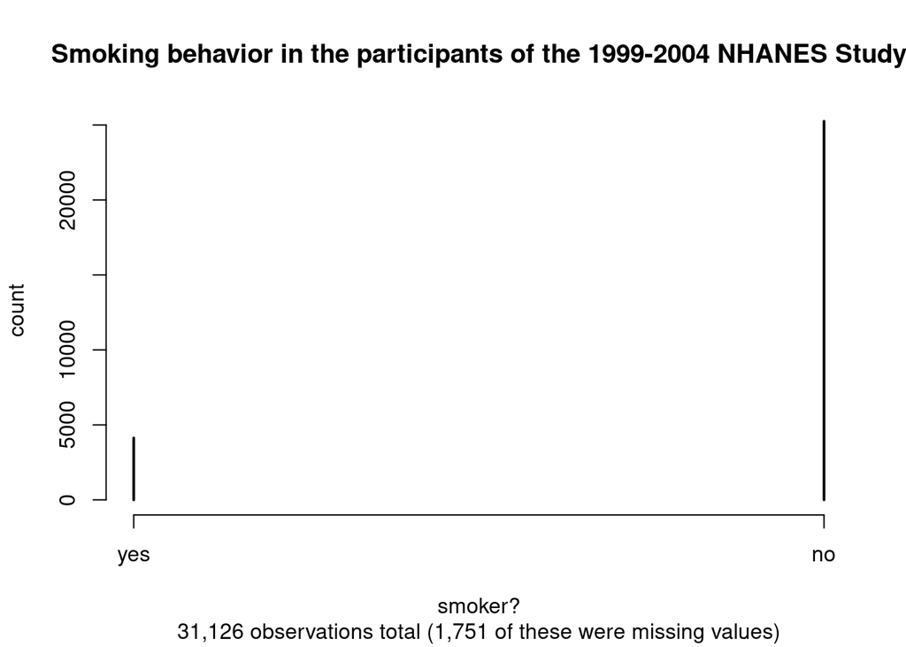

```r
plot(table(NHANES$smoker),xlab="smoker?",ylab="count",main="Smoking behavior in the participants of the 1999-2004 NHANES Study",sub="31,126 observations total (1,751 of these were missing values)")
```

Honestly I am still not satisfied with this graph (now we are moving into aesthetics). If the number of levels is too small then plotting a table with this technique creates an image with too much empty space (at least to my mind). Let’s fix that problem using `barplot()`:

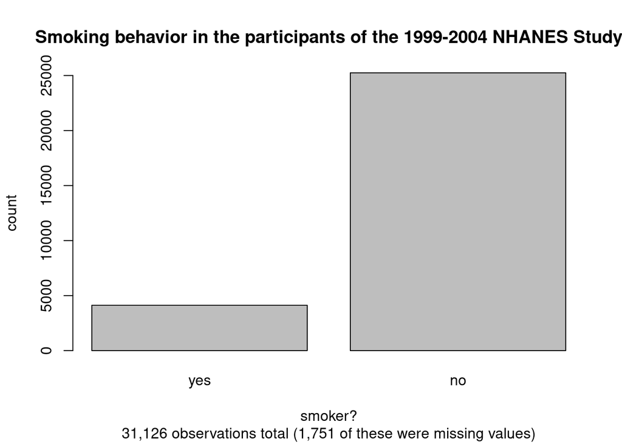

```r
barplot(table(NHANES$smoker),xlab="smoker?",ylab="count",main="Smoking behavior in the participants of the 1999-2004 NHANES Study",sub="31,126 observations total (1,751 of these were missing values)")
```

**A warning**: The function `barplot()` works well for categorical data, and it even serves reasonably well when the data has a natural order (ordinal data) to it (think ‘first’, ‘second’, and ‘third’), however **you** are responsible for ensuring that the data is in the proper order. Even more importantly– it is also up to you to deal with missing values or uneven spacing between the columns. The first nested expression that we used, `plot(table())`, is better for numeric data– particularly when there are more than just a few values.

**Question for Problem 1:**

1. **Create barplots** out of the frequency-tables for the remaining four categorical variables. Be sure your axis are appropriately labeled and the number of missing values is reported somewhere. **Include** the number of missing elements using `sub=` for at least one of the variables. Investigate the arguments that `barplot()` understands using `?barplot`, and **incorporate** a few in your graphs (changing colors is always fun).

##### Solution

```r
#Answer to Problem 1:
table(NHANES$sex)
```

```
##
##   male female
##  15184  15942
```

```r
length(NHANES$sex)
```

```
## [1] 31126
```

```r
sum(is.na(NHANES$sex))
```

```
## [1] 0
```

```r
head(NHANES$sex)
```

```
## [1] female male   female male   male   female
## Levels: male female
```

```r
head(is.na(NHANES$sex))
```

```
## [1] FALSE FALSE FALSE FALSE FALSE FALSE
```

```r
sum(is.na(NHANES$sex))
```

```
## [1] 0
```

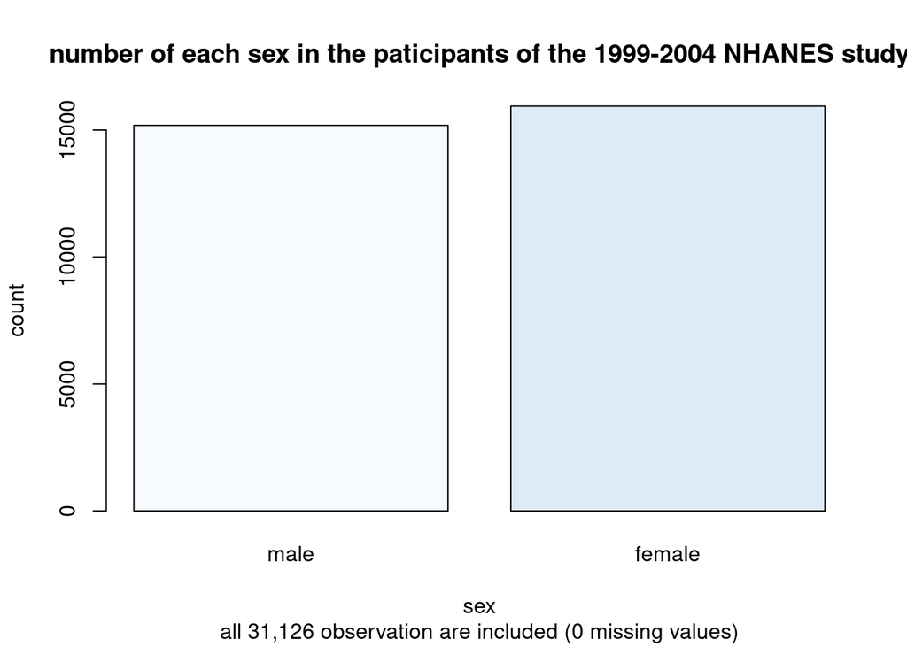

```r
barplot(table(NHANES$sex), xlab = "sex", ylab = "count", main = "number of each sex in the paticipants of the 1999-2004 NHANES study", sub = "all 31,126 observation are included (0 missing values)", col = blues9)
```

```r
table(NHANES$pregnant)
```

```
##
##   yes    no
##   968 30158
```

```r
length(NHANES$pregnant)
```

```
## [1] 31126
```

```r
sum(is.na(NHANES$pregnant))
```

```
## [1] 0
```

```r
head(NHANES$pregnant)
```

```
## [1] no no no no no no
## Levels: yes no
```

```r
head(is.na(NHANES$pregnant))
```

```
## [1] FALSE FALSE FALSE FALSE FALSE FALSE
```

```r
sum(is.na(NHANES$pregnant))
```

```
## [1] 0
```

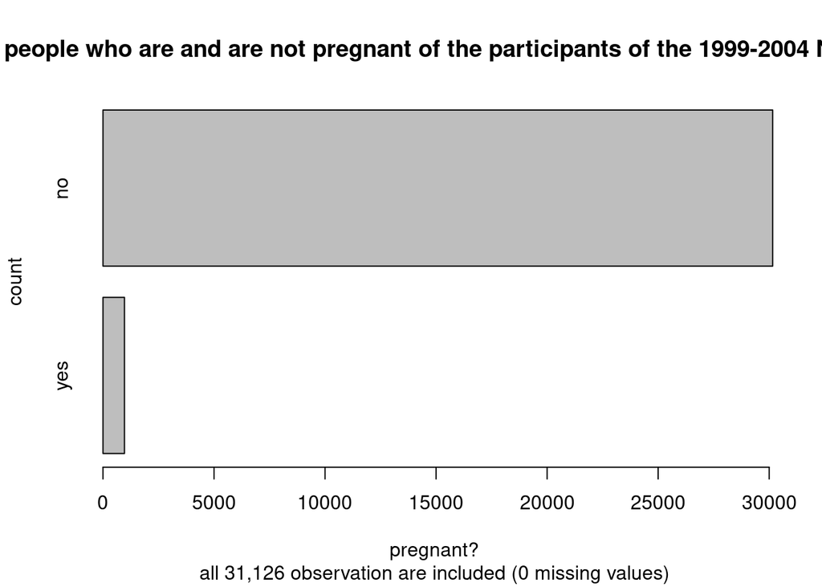

```r
barplot(table(NHANES$pregnant), xlab = "pregnant?", ylab = "count", main = "number of people who are and are not pregnant of the participants of the 1999-2004 NHANES study", sub = "all 31,126 observation are included (0 missing values)", horiz = TRUE)
```

```r
table(NHANES$death)
```

```
##
##                alive                other cardiovascular death
##                15706                  818                  515
```

```r
length(NHANES$death)
```

```
## [1] 31126
```

```r
sum(is.na(NHANES$death))
```

```
## [1] 14087
```

```r
head(NHANES$death)
```

```
## [1] <NA>  alive <NA>  <NA>  alive alive
## Levels: alive other cardiovascular death
```

```r
head(is.na(NHANES$death))
```

```
## [1]  TRUE FALSE  TRUE  TRUE FALSE FALSE
```

```r
sum(is.na(NHANES$death))
```

```
## [1] 14087
```

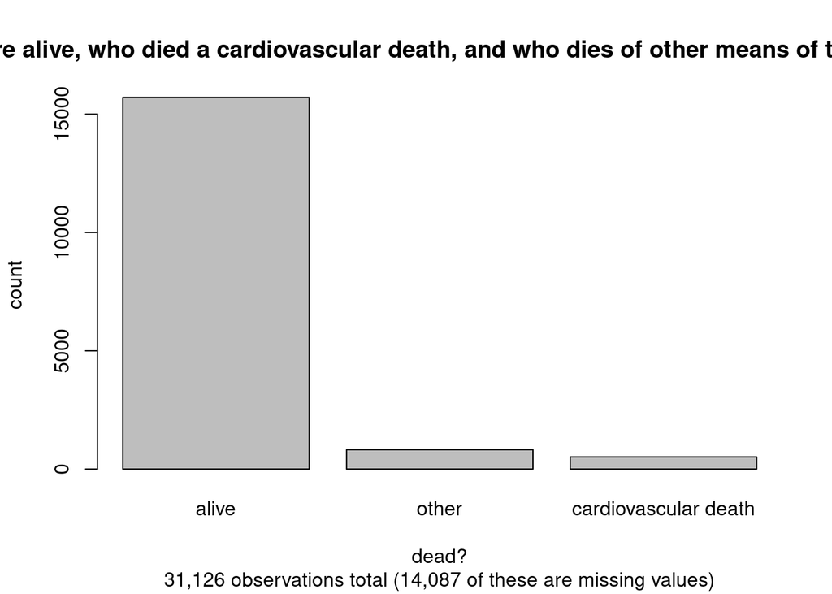

```r
barplot(table(NHANES$death), xlab = "dead?", ylab = "count", main = "number of people who are alive, who died a cardiovascular death, and who dies of other means of the 1999-2004 NHANES study", sub = "31,126 observations total (14,087 of these are missing values)", border = TRUE)
```

```r
table(NHANES$diabetic)
```

```
##
##     0     1
## 27795  1580
```

```r
length(NHANES$diabetic)
```

```
## [1] 31126
```

```r
sum(is.na(NHANES$diabetic))
```

```
## [1] 1751
```

```r
head(NHANES$diabetic)
```

```
## [1] 0 0 0 0 0 0
```

```r
head(is.na(NHANES$diabetic))
```

```
## [1] FALSE FALSE FALSE FALSE FALSE FALSE
```

```r
sum(is.na(NHANES$diabetic))
```

```
## [1] 1751
```

[figure not shown]

```r
barplot(table(NHANES$diabetic), xlab = "diabetic?", ylab = "count", main = "number of people who are and are not diabetic of the 1999-2004 NHANES study", sub = "31,126 observations total (1,751 of these are missing values)", density = 1)
```

##### Problem 2. (25 points)

The `table()` command can produce **contingency tables** as well. It’s easiest to understand with an example:

```r
table(NHANES$smoker,NHANES$ethnicity)
```

```
##
##       Mexican American Other Hispanic Non-Hispanic White Non-Hispanic Black
##   yes              838            185               1972                961
##   no              7240           1161               9543               6273
##
##       Other/Multi
##   yes         170
##   no         1032
```

A **mosaic** plot (see http://en.wikipedia.org/wiki/Mosaic_plot) is a great way to visually detect *associations* between categorical variables that might be hidden inside the numeric data of the table.

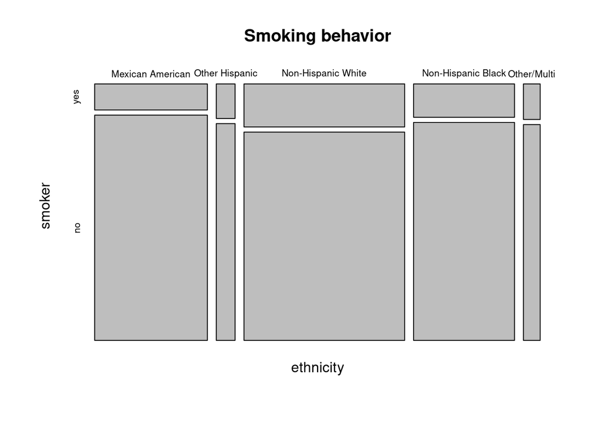

```r
mosaicplot(table(NHANES$ethnicity,NHANES$smoker),main="Smoking behavior",ylab="smoker",xlab="ethnicity")
```

The areas are proportional to the values in the contingency table. The rectangle with the largest area (Non-Hispanic White’s that don’t smoke) corresponds to 9543– the largest number in the contingency table.

**Questions for Problem 2:** *Interweave your solutions amongst the questions*

1. Using the mosaic plot provided above **answer** the following questions. In the one case that has some ambiguity generate the table and use that to provide your answer– your document should include the R-code for generating the table and the output:
- Which ethnic group had the highest participation in the study? non Hispanic white
- Which category of smoking behavior was the most common (smoking or non-smoking)? non-smoking
- Which ethnic group had the lowest *proportion* of smokers? Mexican american
- Which ethnic group had the lowest *total number* of smokers? other/multi
2. **Produce** mosaic plots comparing
- ethnicity and smoking behavior,
- ethnicity and diabetes status,
- smoking behavior and diabetes.

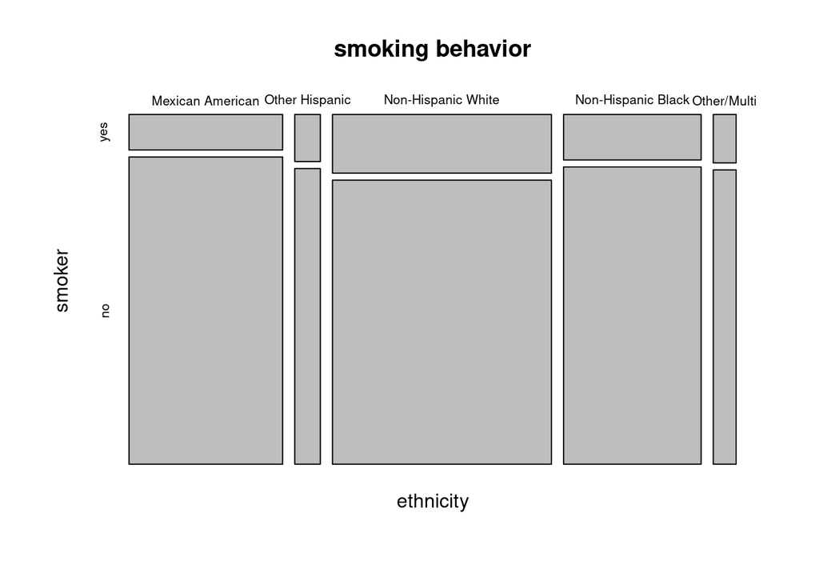

```r
mosaicplot(table(NHANES$ethnicity, NHANES$smoker), main = "smoking behavior", ylab = "smoker", xlab = "ethnicity")
```

```r
mosaicplot(table(NHANES$ethnicity, NHANES$diabetic), main = "diabetic behavior", ylab = "diabetic", xlab = "ethnicity")
```

[output not shown]

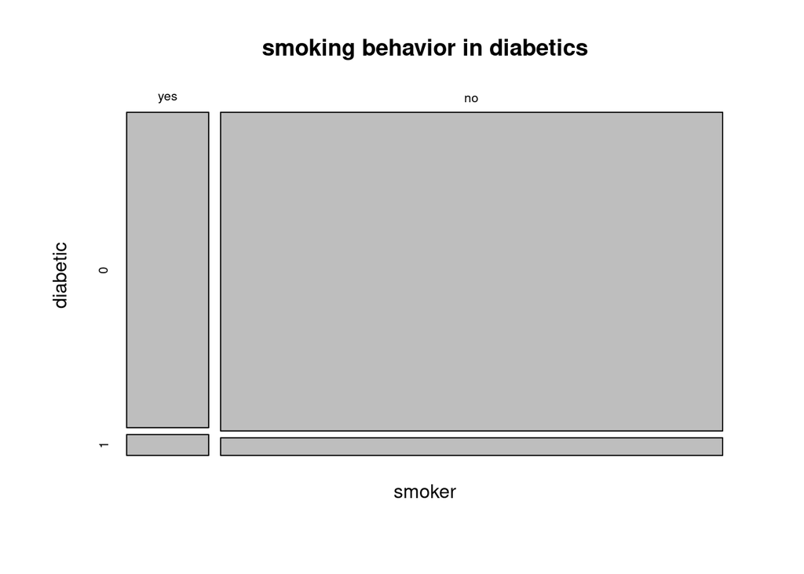

```r
mosaicplot(table(NHANES$smoker, NHANES$diabetic), main = "smoking behavior in diabetics", ylab = "diabetic", xlab = "smoker")
```

3. **Discuss** what you observe in those three mosaic plots. Be sure to comment on *similarities* as well as *differences*. In particular, what do you notice about the rates of diabetes amongst the various ethnic groups?

Diabetics seem to have a slightly higher proportion of smokers then people without. all the ethnic groups seem to have the same proportion of diabetics. other/multi look like they have a slightly less proportion of diabetics then the rest.

4. **Produce** a mosaic plot comparing ethnicity, smoking behavior, and presence of diabetes (you will need to provide 3 variables to the `table()` function). Experiment with the order of the data in the `table()` portion of the command to find the best way to see the information.

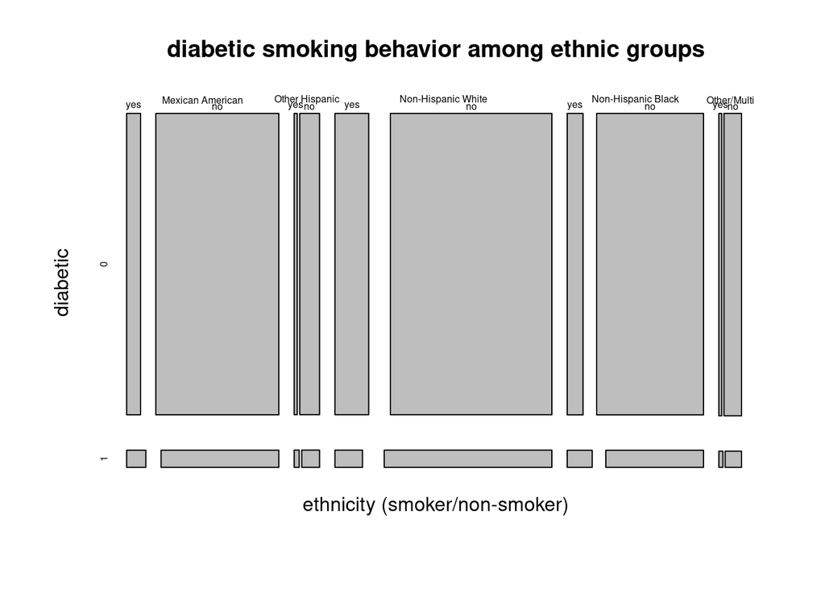

```r
#mosaicplot(table(NHANES$ethnicity, NHANES$smoker, NHANES$diabetic), main = "smoking behavior", ylab = "smoker", xlab = "ethnicity")
mosaicplot(table(NHANES$ethnicity, NHANES$diabetic, NHANES$smoker), cex.axis = 0.5, main = "diabetic smoking behavior among ethnic groups", ylab = "diabetic", xlab = "ethnicity (smoker/non-smoker)")
```

```r
#mosaicplot(table(NHANES$smoker, NHANES$diabetic, NHANES$ethnicity), main = "smoking behavior in diabetics", ylab = "diabetic", xlab = "smoker")
```

5. **Explore** the data using the graph– what relationships appear to be present? Which relationships from part 3 are still easy to discern, which are hidden? Do any new relationships appear?

## In every ethnic group besides non-Hispanic whites, diabetics seem to smoke more. Its still easy to see like in part three, the proportion of diabetics are still very similar in every ethnic group.

##### Problem 3. (4 points)

In the last problem, hints of unexpected relationships began appearing when we considered the mosaic plot involving 3 factors. Add the named argument `shade=TRUE` to your mosaic plot from Problem 2.4 (it may take some work to figure out *exactly* where to place the argument– perservere and don’t be afraid to use R’s help functions). The result will indicate an over-abundance with blue and an under-abundance with red. You might be a bit surprised by what you see. Provide the graph and your interpretation.

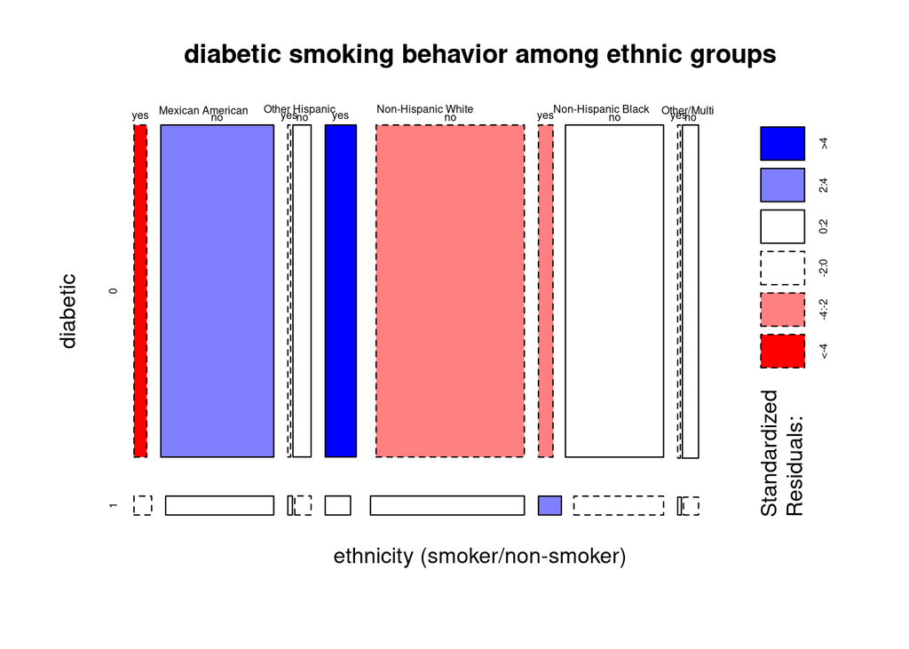

```r
#Answer to Problem 3
mosaicplot(table(NHANES$ethnicity, NHANES$diabetic, NHANES$smoker), cex.axis = 0.5, shade = TRUE, main = "diabetic smoking behavior among ethnic groups", ylab = "diabetic", xlab = "ethnicity (smoker/non-smoker)")
```

## blue means there are more observations then what was expected. Red mean there were fewer observations then what was expected. There was a large number of observations then what was expected of non-Hispanic whites that do smoke and are not diabetic. There was also slightly more observations then what was expected of Mexican Americans that don’t smoke and are not diabetic along with observations of non-Hispanic blacks that do smoke and are diabetic. On the other side, there was a lot less observations then what was expected of Mexican Americans that do smoke and are not diabetic. There was also slightly less then expected observations of non-Hispanic whites that dont smoke and are not diabetic along with observations of non-Hispanic blacks that do smoke and are not diabetic.

##### Problem 4. (5 points)

In fact, you might start to question a lot of things… perhaps you show your mosaic plots (from problem 2.2) to a friend that knows a thing or two about diabetes and instead of looking suitably impressed they frown a bit and say… “that’s not right– everybody knows that black Americans have a much higher risk for diabetes than non-Hispanic white Americans, and the Native Americans have it even worse!” Is your friend right?

**Questions for Problem 4:** *Interweave your solutions amongst the questions*

1. Do some **research**. Go to http://www.diabetes.org/diabetes-basics/statistics/ and find the reported percentages by ethnicity. Provide those.

American Indians/Alaskan Natives- 14.5% Non-Hispanic blacks- 12.1% Hispanics- 11.8% Asian Americans- 9.5% Non-Hispanic whites- 7.4%

2. There was no discussion of the sex of the individuals in those statistics… Perhaps one sex is more prone than the other and the differences between the ethnic groups are being drowned out by not including sex. A 4-factor mosiac plot seems to be a bit much… Dig around at https://web.archive.org/web/20151209090156/http://www.cdc.gov/diabetes/statistics/prevalence_national.htm and report what you find about the differences in diabetes rates between men and women (broken down by ethnicity). You might notice that the link above is to an archive. That’s because the CDC has introduced some snazzy new features… but they did NOT include a breakdown by sex **and** ethnicity (http://www.cdc.gov/diabetes/statistics/prevalence_national.htm).

White and asian males have a higher diabetes then females. Especially over the past 20 years or so. in the 80s white males and females were very similar but around the 2000s mens rates increased more then women. however, black female rates of diabetes are higher then black mens rates.

##### Problem 5. (7 points)

At that last site, the term “age-corrected” appeared fairly frequently… perhaps there’s something strange about the ages in our data. Let’s start by looking at the ages of **everybody**. As usual, we’ll use `table()` to prepare the data for `barplot()`, and access the variables (cols) in a data frame using the dollar-sign `$` construction:

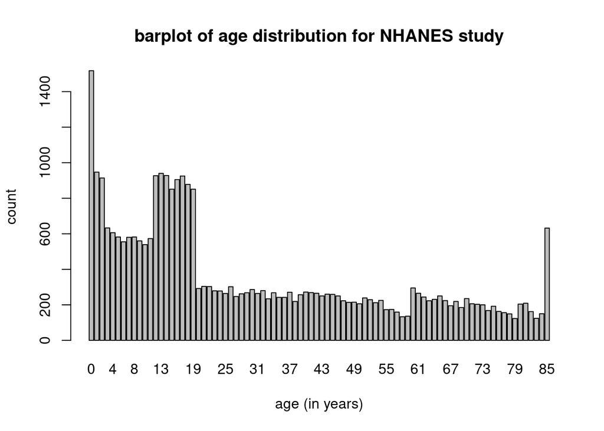

```r
barplot(table(NHANES$age),xlab="age (in years)",ylab="count",main="barplot of age distribution for NHANES study")
```

We can also use `boxplot()` to view a summary of the data without using `table()`.

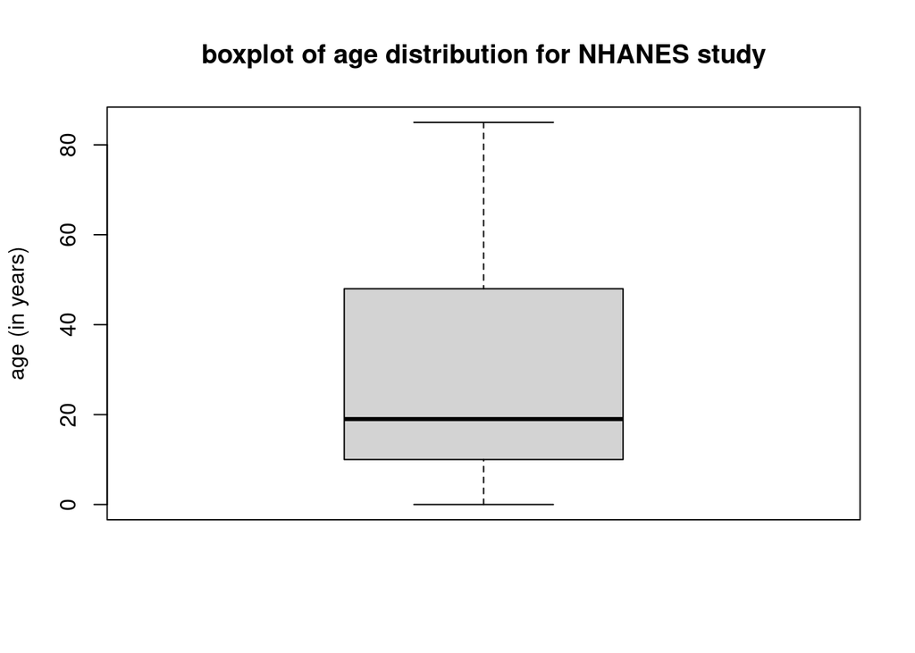

```r
boxplot(NHANES$age,ylab="age (in years)",main="boxplot of age distribution for NHANES study")
```

If the variable doesn’t have too many distinct values (or any skipped values) then a barplot can still be very informative for discrete numeric data… The `plot(table())` construction is a bit smarter– it will leave a gap when ages are missing– something the `barplot()` command does not do unless you personally prepare the data yourself.

When the number of possible values in the variable grows too high then a `barplot()` becomes uninformative– a histogram may be a better way to look for patterns in the values, however, for a bird’s-eye view, the `boxplot()` works no matter how complicated the data. It is useful for a broad overview, but it hides many of the details. However, it is **very** easy to produce multiple boxplots of a variable that are broken down by category:

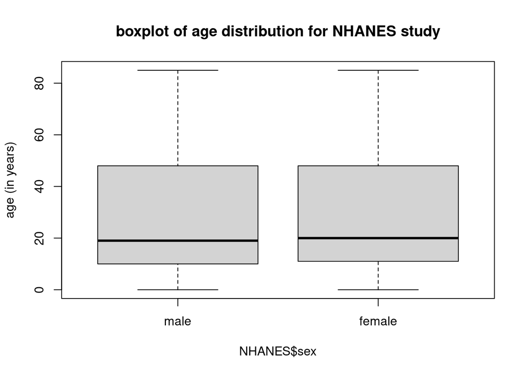

```r
boxplot(NHANES$age~NHANES$sex,ylab="age (in years)",main="boxplot of age distribution for NHANES study")
```

or, here by smoking:

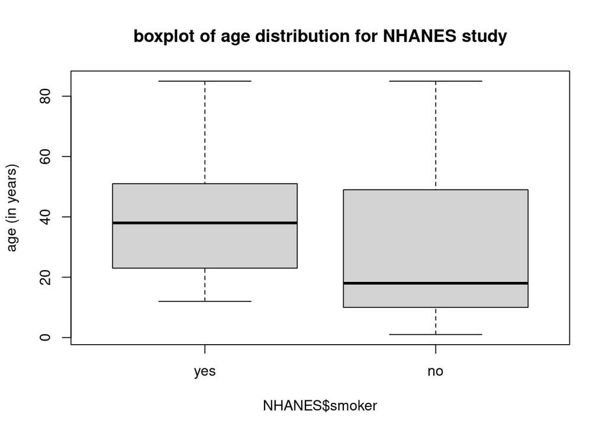

```r
boxplot(NHANES$age~NHANES$smoker,ylab="age (in years)",main="boxplot of age distribution for NHANES study")
```

**Questions for Problem 5** *Interweave your solutions amongst the questions*

1. Make a side-by-side barplot of ages broken down by smoking behavior on the same graph(use `beside=TRUE`)

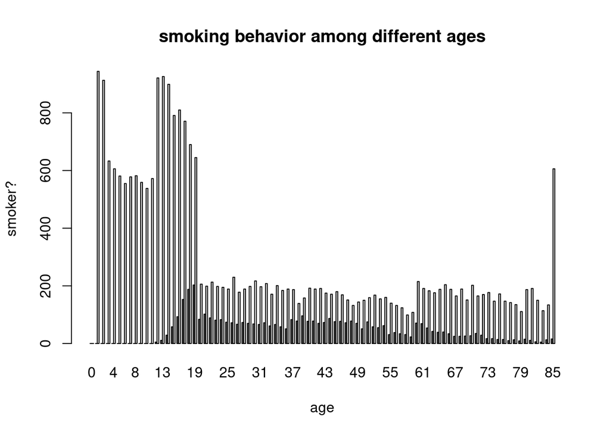

```r
barplot(table(NHANES$smoker, NHANES$age), beside = TRUE, main = "smoking behavior among different ages", ylab = "smoker?", xlab = "age")
```

2. Make a side-by-side boxplot of ages broken down by diabetic status

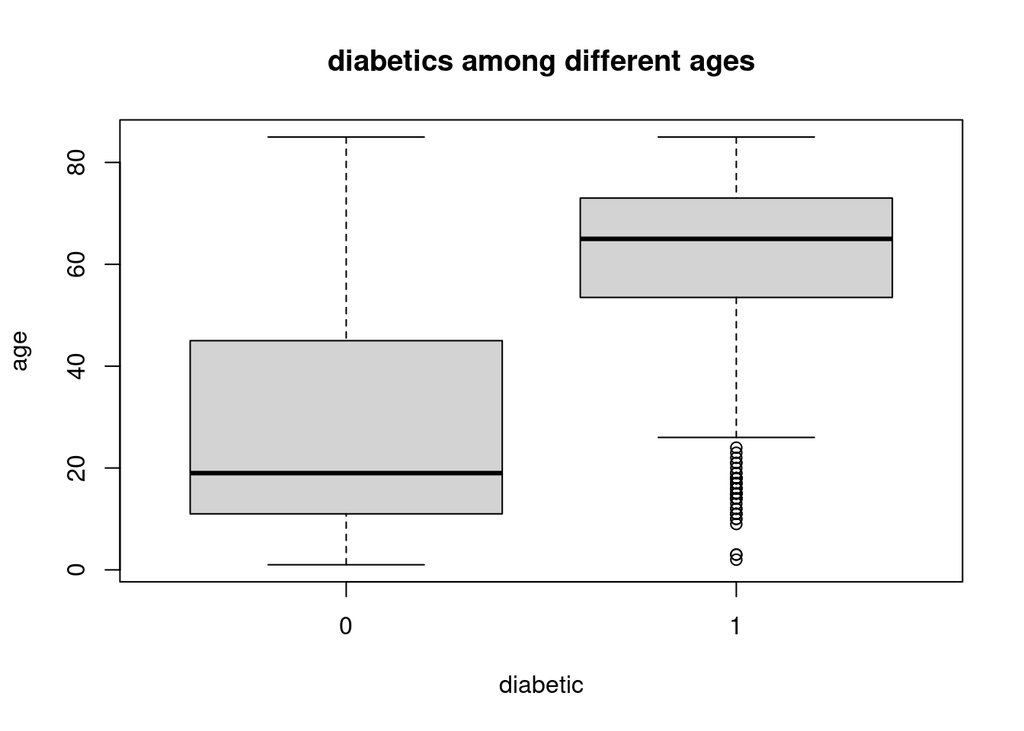

```r
boxplot(NHANES$age~NHANES$diabetic, main = "diabetics among different ages", ylab = "age", xlab = "diabetic")
```

3. Make a side-by-side boxplot of ages broken down by ethnicity. You will likely need to use `cex.axis=0.7` (or something similar) to make sure all the labels are visible

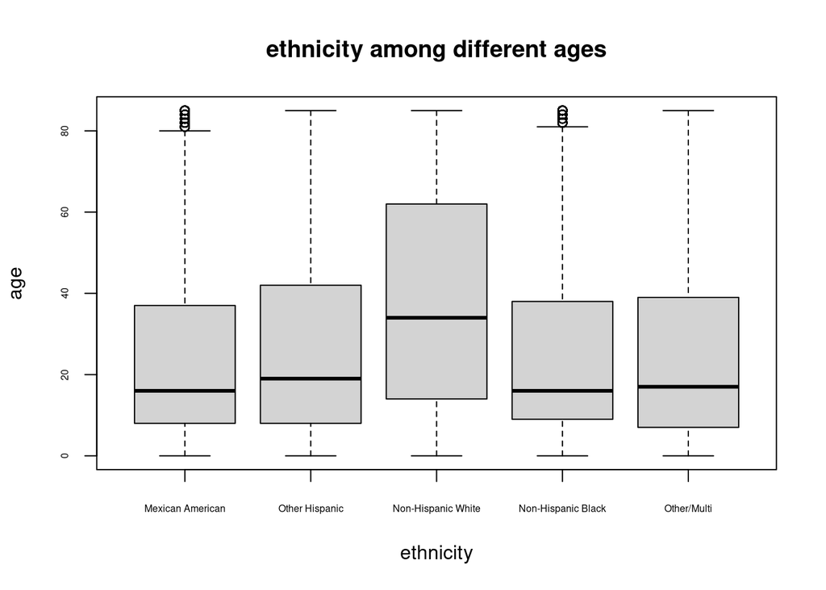

```r
boxplot(NHANES$age~NHANES$ethnicity, main = "ethnicity among different ages", ylab = "age", xlab = "ethnicity", cex.axis=0.5)
```

##### Problem 6. (18 points)

Hey! Not only did we find a strange peak in the ages of the study participants, your latest side-by-side boxplot shows that the age distribution of Non-hispanic White’s is fundamentally different than the other ethnic groups. Let’s learn how to limit our data.

R has many, many ways of extracting data that satisfies some collection of criteria. We can use one variable in a data frame to *categorize* another variable in the same data frame (like we did in the `boxplot()` examples. This time we want to make a new table with a smaller number of entries. Let’s do that for each of the sexes and make distinct barplots (not boxplots) of the ages– one for each sex.

Let’s start by looking at the first few entries in the age column and the first few entries in the sex column:

```r
head(NHANES$age)
```

```
## [1]  2 77 10  1 49 19
```

```r
head(NHANES$sex)
```

```
## [1] female male   female male   male   female
## Levels: male female
```

It’s a bit hard to see which entries are supposed to line up, so I’ll show you the first few in table form:

```
##   age    sex
## 1   2 female
## 2  77   male
## 3  10 female
## 4   1   male
## 5  49   male
## 6  19 female
```

We can **limit** which entries make it to the `barplot()` function (for display) by using the square brackets, `[]`. In the example below, the variable `NHANES$sex` is compared to the value “female”. Every `NHANES$age` for which `NHANES$sex` is “female” will be kept. It’s essentially the same thing as we saw in the first problem– `NHANES$sex=="female"` is a vector of logicals… each age that lines up with a `TRUE` will be kept, and the rest discarded:

```r
head(NHANES$age[NHANES$sex=="female"])
```

```
## [1]  2 10 19 59 11 38
```

See how that works? Now we can pass this off to `barplot()`:

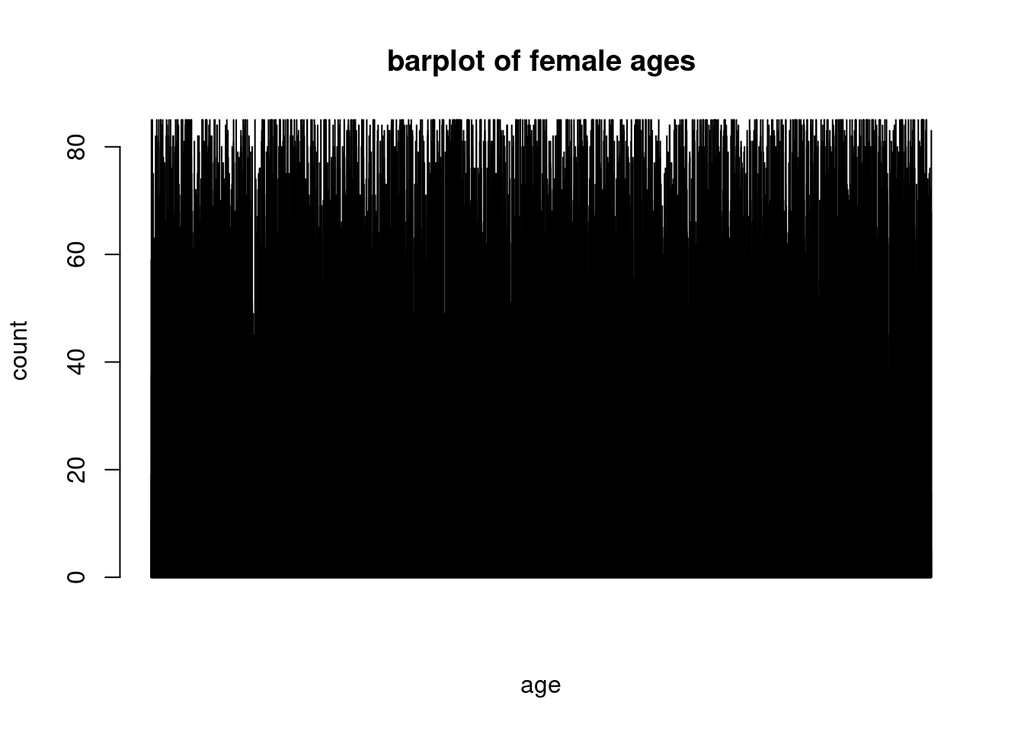

```r
barplot(NHANES$age[NHANES$sex=="female"],main="barplot of female ages",xlab="age",ylab="count")
```

Wait! that looks horrible! What happened? Oh, right we need to **prepare** the data using `table()`:

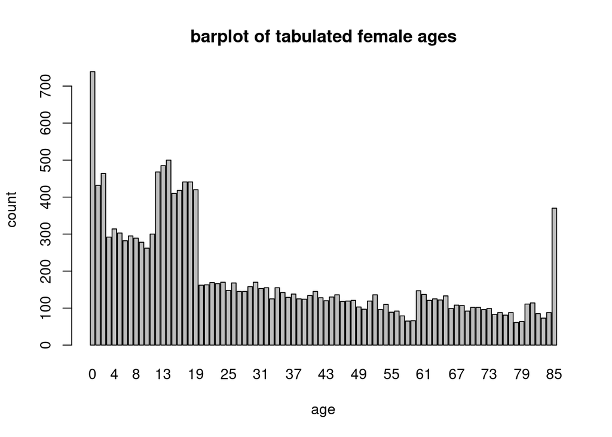

```r
barplot(table(NHANES$age[NHANES$sex=="female"]),main="barplot of tabulated female ages",xlab="age",ylab="count")
```

Now, if we want to show BOTH we can use the `table()` function to prepare the data, but this time we will use more arguments:

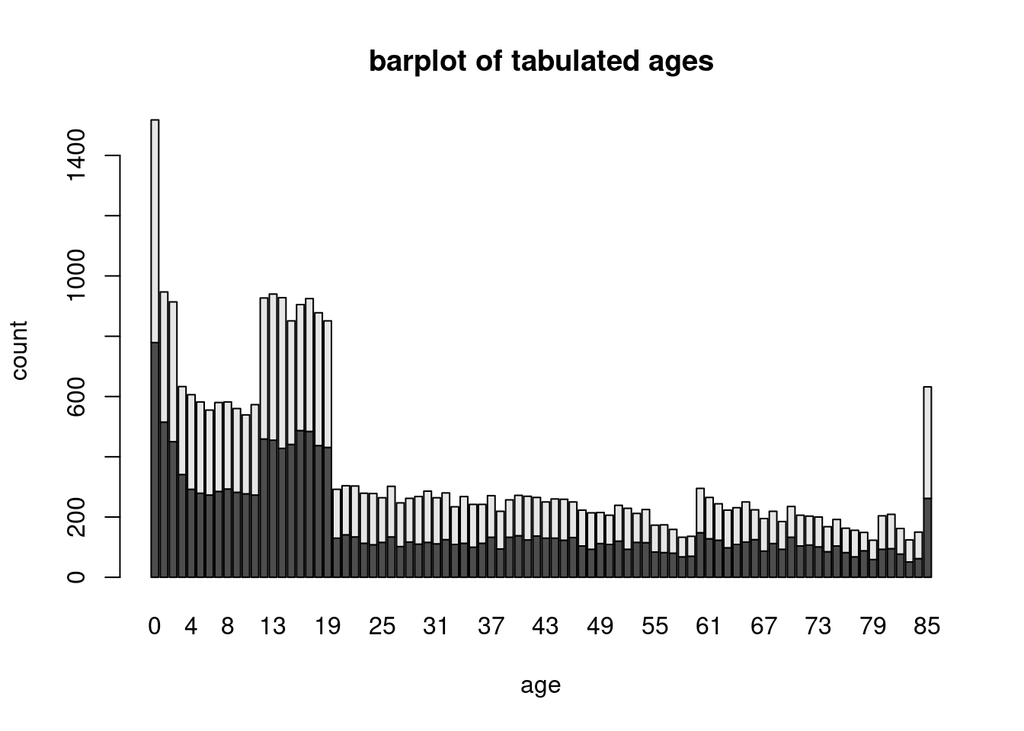

```r
barplot(table(NHANES$sex,NHANES$age),main="barplot of tabulated ages",xlab="age",ylab="count")
```

Hmph… I see several problems. First, we have no way of knowing how to interpret the colors, and second, we have generated a stacked barplot– sometimes this is fine, but other times (particularly when the data is not particularly smooth), it can be a bit hard to tell what’s happening.

Let’s fix the first problem using the `legend=TRUE` named argument:

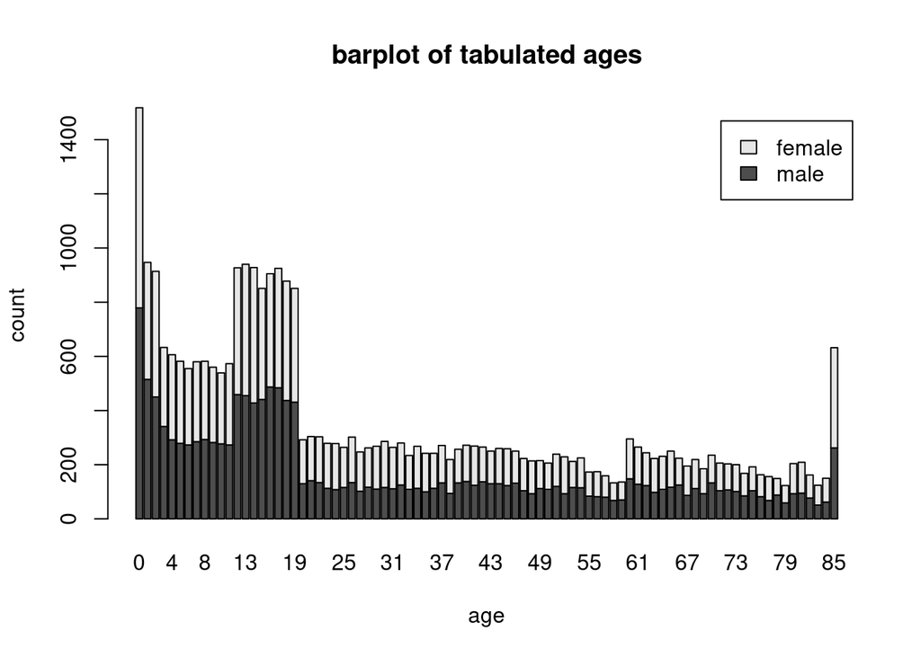

```r
barplot(table(NHANES$sex,NHANES$age),main="barplot of tabulated ages",xlab="age",ylab="count",legend=TRUE)
```

As for the second– we can use the `beside=TRUE` named argument:

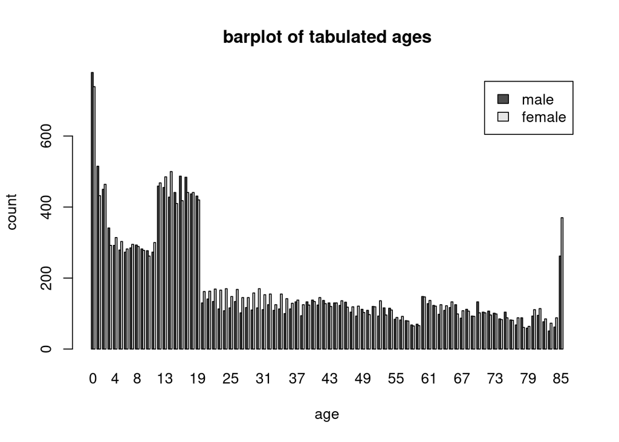

```r
barplot(table(NHANES$sex,NHANES$age),main="barplot of tabulated ages",xlab="age",ylab="count",legend=TRUE,beside=TRUE)
```

That’s a bit better… although we are coming dangerously close to the limits of what the human eye can discern. A few things, however, are immediately obvious– the number of women is higher in the 19-35ish range than the men (and also in the oldest segments of the populations).

**Questions for Problem 6:** *Interweave your solutions amongst the questions*

1. Barplot of ages:
   - Make a barplot of the tabulated ages of the men

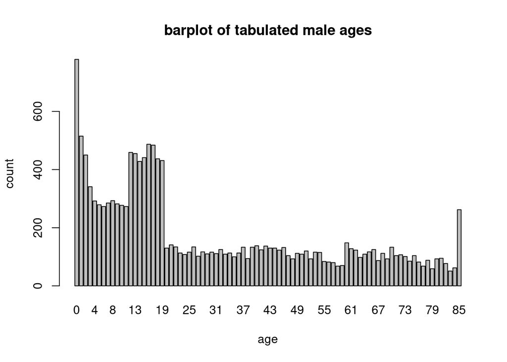

```r
barplot(table(NHANES$age[NHANES$sex=="male"]), main = "barplot of tabulated male ages", xlab = "age", ylab = "count")
```

* Make a barplot of the tabulated ages of the smokers

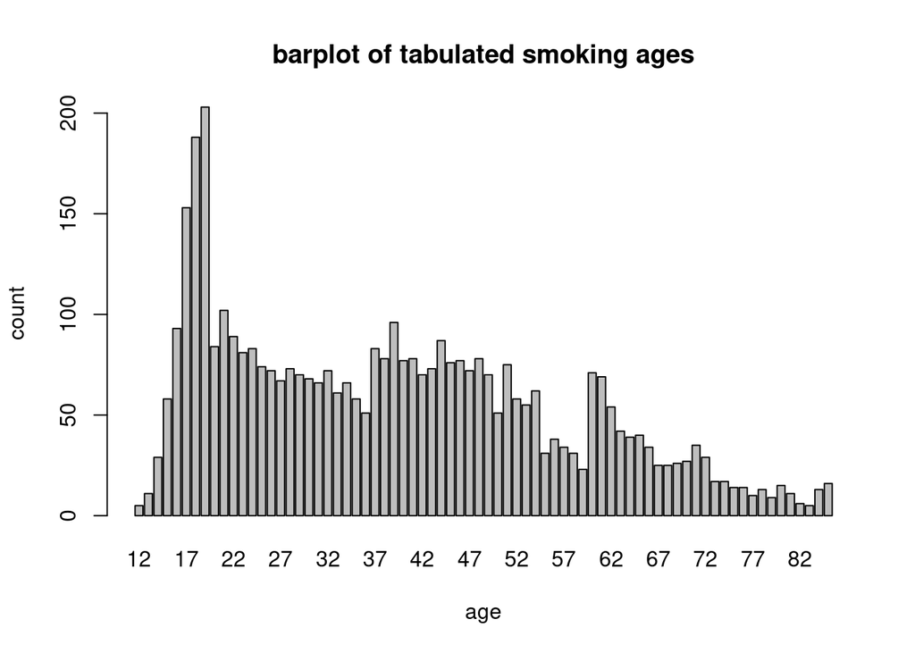

```r
barplot(table(NHANES$age[NHANES$smoker=="yes"]), main = "barplot of tabulated smoking ages", xlab = "age", ylab = "count")
```

* Make a barplot of the tabulated ages of the non-smokers

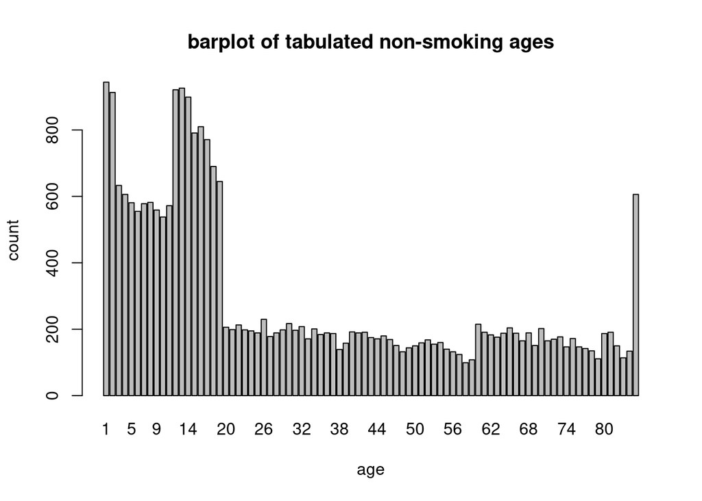

```r
barplot(table(NHANES$age[NHANES$smoker=="no"]), main = "barplot of tabulated non-smoking ages", xlab = "age", ylab = "count")
```

* Make 4 barplots (use `beside=TRUE`) of tabulated age broken down by ethnicity capturing * 0-19 * 20-39 * 40-59 * 60-

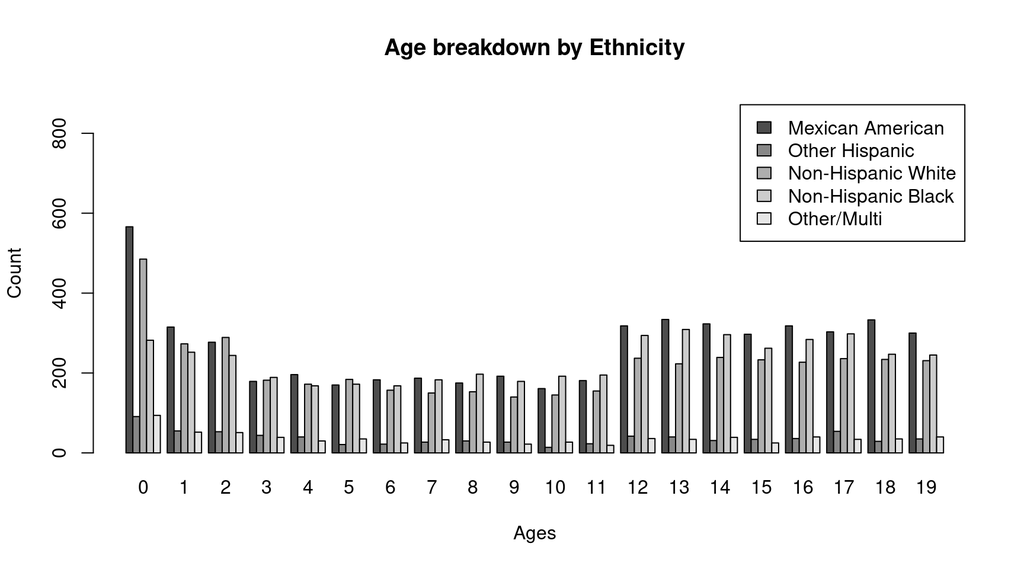

```r
with(NHANES[NHANES$age >= 0 & NHANES$age <= 19,],{barplot(table(ethnicity, age), beside = TRUE, ylim = c(0,900), xlab = "Ages", ylab = "Count", main = "Age breakdown by Ethnicity", legend = TRUE)})
```

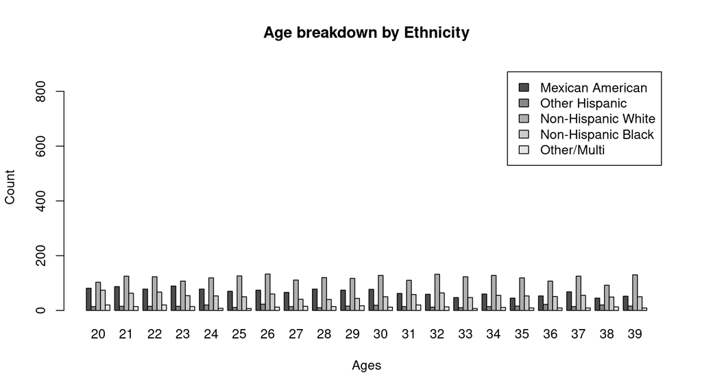

```r
with(NHANES[NHANES$age >= 20 & NHANES$age <= 39,],{barplot(table(ethnicity, age), beside = TRUE, ylim = c(0,900), xlab = "Ages", ylab = "Count", main = "Age breakdown by Ethnicity", legend = TRUE)})
```

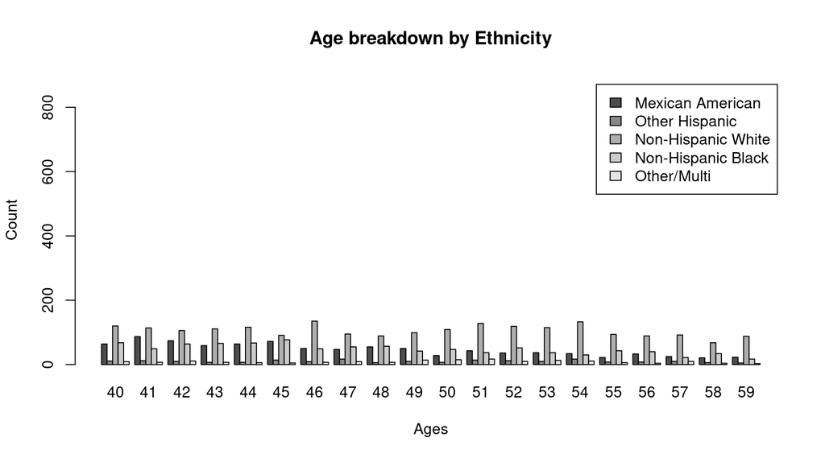

```r
with(NHANES[NHANES$age >= 40 & NHANES$age <= 59,],{barplot(table(ethnicity, age), beside = TRUE, ylim = c(0,900), xlab = "Ages", ylab = "Count", main = "Age breakdown by Ethnicity", legend = TRUE)})
```

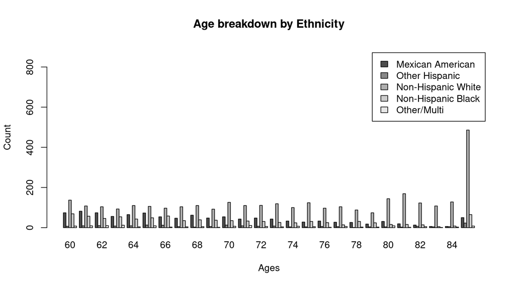

```r
with(NHANES[NHANES$age >= 60,],{barplot(table(ethnicity, age), beside = TRUE,ylim = c(0,900), xlab = "Ages", ylab = "Count", main = "Age breakdown by Ethnicity", legend = TRUE)})
```

2. Some questions about the distribution of ages
   - Is the distribution of ages of people participating in the study consistent across sex? Remark on any patterns you see.

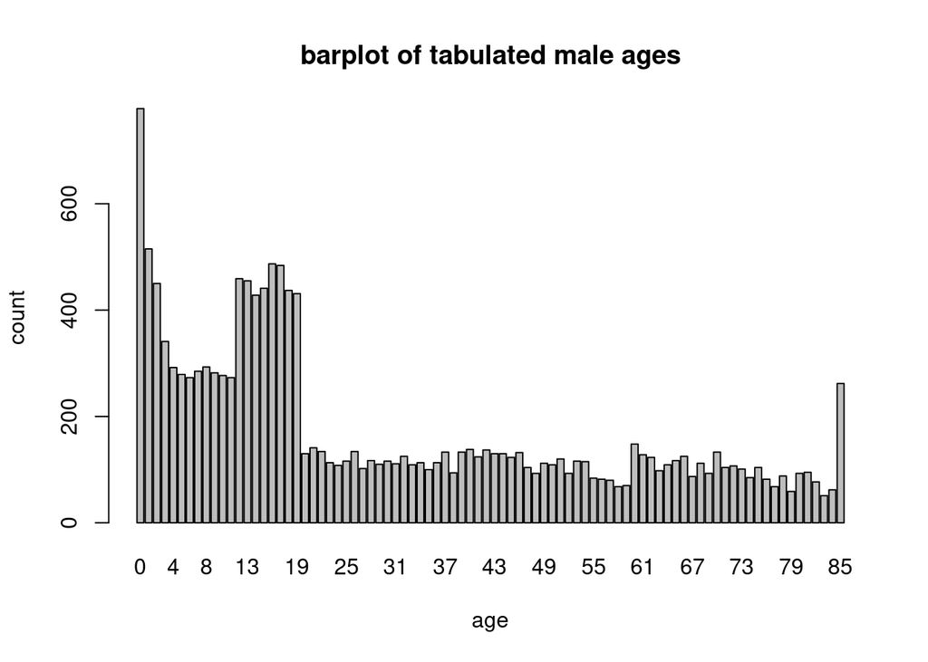

```r
barplot(table(NHANES$age[NHANES$sex=="male"]), main = "barplot of tabulated male ages", xlab = "age", ylab = "count")
```